# Global_Educational_Disparities_Examining_Out_of_School_Youth_Rates_(Keerthan)

## title: "Global Educational Disparities: Examining Out-of-School Youth Rates" subtitle: "A Data Analysis Report for UNICEF" author: "UNICEF Data Analysis Team" date: "April 20, 2025" format: html: embed-resources: true code-fold: true toc: true toc-depth: 3 theme: cosmo highlight-style: github fig-width: 10 fig-height: 6

## Introduction {.unnumbered}

This report examines the critical issue of **out-of-school youth** around the world, with a particular focus on upper secondary school age individuals. Education is a fundamental right and a key driver of development, yet millions of adolescents worldwide remain excluded from educational opportunities. This analysis aims to highlight the disparities in educational access across different regions and demographic groups, providing insights that can inform policy decisions and intervention strategies.

The analysis focuses on:

1. Geographic distribution of out-of-school rates
2. Gender disparities in educational access
3. Relationship between economic factors and education
4. Changes in educational access over time

By understanding these patterns, UNICEF can better target resources and advocacy efforts to reach the most vulnerable populations and advance progress toward universal education.

## Data Preparation and Exploration

First, let's import the necessary libraries and load our datasets.

```python
# Import necessary libraries
import pandas as pd
import numpy as np
import plotnine as p9
from plotnine import *
import matplotlib.pyplot as plt
from matplotlib.colors import LinearSegmentedColormap
import warnings

# Suppress warnings for cleaner output
warnings.filterwarnings('ignore')

# Load the datasets
education_data = pd.read_csv('unicef_indicator_2-1.csv')
metadata = pd.read_csv('unicef_metadata.csv')

# Display the first few rows of each dataset
print("Education Data Sample:")
education_data.head()
```

```
Education Data Sample:
```

|  | country | alpha_2_code | alpha_3_code | numeric_code | indicator | time_period | obs_value | sex | unit_multiplier | unit_of_measure | observation_status | observation_confidentaility | time_period_activity_related_to_when_the_data_are_collected | current_age |
| --- | --- | --- | --- | --- | --- | --- | --- | --- | --- | --- | --- | --- | --- | --- |
| 0 | Afghanistan | AF | AFG | 4 | Out-of-school rate for youth of upper secondar... | 2015 | 72.725258 | Female | NaN | % | NaN | NaN | NaN | Total |
| 1 | Afghanistan | AF | AFG | 4 | Out-of-school rate for youth of upper secondar... | 2015 | 42.885769 | Male | NaN | % | NaN | NaN | NaN | Total |
| 2 | Afghanistan | AF | AFG | 4 | Out-of-school rate for youth of upper secondar... | 2015 | 57.790981 | Total | NaN | % | NaN | NaN | NaN | Total |
| 3 | Albania | AL | ALB | 8 | Out-of-school rate for youth of upper secondar... | 2018 | 12.000000 | Female | NaN | % | NaN | NaN | NaN | Total |
| 4 | Albania | AL | ALB | 8 | Out-of-school rate for youth of upper secondar... | 2018 | 12.400000 | Male | NaN | % | NaN | NaN | NaN | Total |

```python
print("Metadata Sample:")
metadata.head()
```

```
Metadata Sample:
```

|  | country | alpha_2_code | alpha_3_code | numeric_code | year | Population, total | GDP per capita (constant 2015 US$) | GNI (current US$) | Inflation, consumer prices (annual %) | Life expectancy at birth, total (years) | Military expenditure (% of GDP) | Fossil fuel energy consumption (% of total) | GDP growth (annual %) | Birth rate, crude (per 1,000 people) | Hospital beds (per 1,000 people) |
| --- | --- | --- | --- | --- | --- | --- | --- | --- | --- | --- | --- | --- | --- | --- | --- |
| 0 | Afghanistan | AF | AFG | 4 | 1960 | 9035043.0 | NaN | 5.488888e+08 | NaN | 32.535 | NaN | NaN | NaN | 50.340 | 0.170627 |
| 1 | Afghanistan | AF | AFG | 4 | 1961 | 9214083.0 | NaN | 5.600000e+08 | NaN | 33.068 | NaN | NaN | NaN | 50.443 | NaN |
| 2 | Afghanistan | AF | AFG | 4 | 1962 | 9404406.0 | NaN | 5.577778e+08 | NaN | 33.547 | NaN | NaN | NaN | 50.570 | NaN |
| 3 | Afghanistan | AF | AFG | 4 | 1963 | 9604487.0 | NaN | 7.666667e+08 | NaN | 34.016 | NaN | NaN | NaN | 50.703 | NaN |
| 4 | Afghanistan | AF | AFG | 4 | 1964 | 9814318.0 | NaN | 8.155556e+08 | NaN | 34.494 | NaN | NaN | NaN | 50.831 | NaN |

```python
# Check for missing values
print("Missing values in education data:")
print(education_data.isnull().sum())

print("\nMissing values in metadata:")
print(metadata.isnull().sum())
```

```
Missing values in education data:
country                                                          0
alpha_2_code                                                     3
alpha_3_code                                                     0
numeric_code                                                     0
indicator                                                        0
time_period                                                      0
obs_value                                                        0
sex                                                              0
unit_multiplier                                                339
unit_of_measure                                                  0
observation_status                                             339
observation_confidentaility                                    339
time_period_activity_related_to_when_the_data_are_collected    339
current_age                                                      0
dtype: int64

Missing values in metadata:
country                                           0
alpha_2_code                                      0
alpha_3_code                                      0
numeric_code                                      0
year                                              0
Population, total                                30
GDP per capita (constant 2015 US$)             2542
GNI (current US$)                              2813
Inflation, consumer prices (annual %)          4815
Life expectancy at birth, total (years)         776
Military expenditure (% of GDP)                5805
Fossil fuel energy consumption (% of total)    7686
GDP growth (annual %)                          2621
Birth rate, crude (per 1,000 people)            606
Hospital beds (per 1,000 people)               8787
dtype: int64
```

```python
# Basic statistics for out-of-school rates
education_stats = education_data[education_data['sex'] == 'Total'][['obs_value']].describe()
print("Statistics for Out-of-School Rates (Total):")
education_stats
```

```
Statistics for Out-of-School Rates (Total):
```

|  | obs_value |
| --- | --- |
| count | 113.000000 |
| mean | 29.506229 |
| std | 19.876200 |
| min | 0.600000 |
| 25% | 14.800000 |
| 50% | 24.900000 |
| 75% | 41.614780 |
| max | 86.218826 |

Let's now prepare our data for analysis by merging relevant information and creating the variables we'll need for our visualizations.

```python
# Filter education data for the most recent year per country for total population
ed_latest = education_data[education_data['sex'] == 'Total'].copy()
ed_latest = ed_latest.sort_values('time_period', ascending=False)
ed_latest = ed_latest.drop_duplicates(subset=['country'], keep='first')

# Get the most recent metadata for each country
meta_latest = metadata.copy()
meta_latest = meta_latest.sort_values('year', ascending=False)
meta_latest = meta_latest.drop_duplicates(subset=['country'], keep='first')

# Merge datasets
merged_data = pd.merge(ed_latest, meta_latest, on='country', how='inner')

# Create a dataset for gender comparison
gender_data = education_data[education_data['sex'] != 'Total'].copy()
gender_data = gender_data.sort_values('time_period', ascending=False)
gender_data = gender_data.drop_duplicates(subset=['country', 'sex'], keep='first')

# Get time series data for countries with multiple years
time_data = education_data[education_data['sex'] == 'Total'].copy()
time_data = time_data.sort_values(['country', 'time_period'])

# Display the merged dataset
merged_data.head()
```

|  | country | alpha_2_code_x | alpha_3_code_x | numeric_code_x | indicator | time_period | obs_value | sex | unit_multiplier | unit_of_measure | ... | Population, total | GDP per capita (constant 2015 US$) | GNI (current US$) | Inflation, consumer prices (annual %) | Life expectancy at birth, total (years) | Military expenditure (% of GDP) | Fossil fuel energy consumption (% of total) | GDP growth (annual %) | Birth rate, crude (per 1,000 people) | Hospital beds (per 1,000 people) |
| --- | --- | --- | --- | --- | --- | --- | --- | --- | --- | --- | --- | --- | --- | --- | --- | --- | --- | --- | --- | --- | --- |
| 0 | Algeria | DZ | DZA | 12 | Out-of-school rate for youth of upper secondar... | 2020 | 22.671539 | Total | NaN | % | ... | 46164219.0 | 4660.405457 | 2.440411e+11 | 9.322174 | NaN | 8.171721 | NaN | 4.100000 | NaN | NaN |
| 1 | Belarus | BY | BLR | 112 | Out-of-school rate for youth of upper secondar... | 2020 | 0.750064 | Total | NaN | % | ... | 9178298.0 | 6482.802951 | 6.935218e+10 | 5.000599 | NaN | 1.797703 | NaN | 3.886242 | NaN | NaN |
| 2 | Argentina | AR | ARG | 32 | Out-of-school rate for youth of upper secondar... | 2020 | 6.857804 | Total | NaN | % | ... | 45538401.0 | 12933.249734 | 6.327299e+11 | NaN | NaN | 0.472747 | NaN | -1.611002 | NaN | NaN |
| 3 | Guyana | GY | GUY | 328 | Out-of-school rate for youth of upper secondar... | 2020 | 17.564190 | Total | NaN | % | ... | 826353.0 | 23102.666287 | 1.042159e+10 | 2.821103 | NaN | 0.586517 | NaN | 33.802617 | NaN | NaN |
| 4 | Turks and Caicos Islands | TC | TCA | 796 | Out-of-school rate for youth of upper secondar... | 2020 | 10.598470 | Total | NaN | % | ... | 46198.0 | 20346.655269 | 1.342454e+09 | NaN | NaN | NaN | NaN | 1.199997 | NaN | NaN |

5 rows × 28 columns

## The Global Picture of Out-of-School Youth

### Geographic Distribution of Out-of-School Rates

Let's first examine how out-of-school rates vary across different countries worldwide.

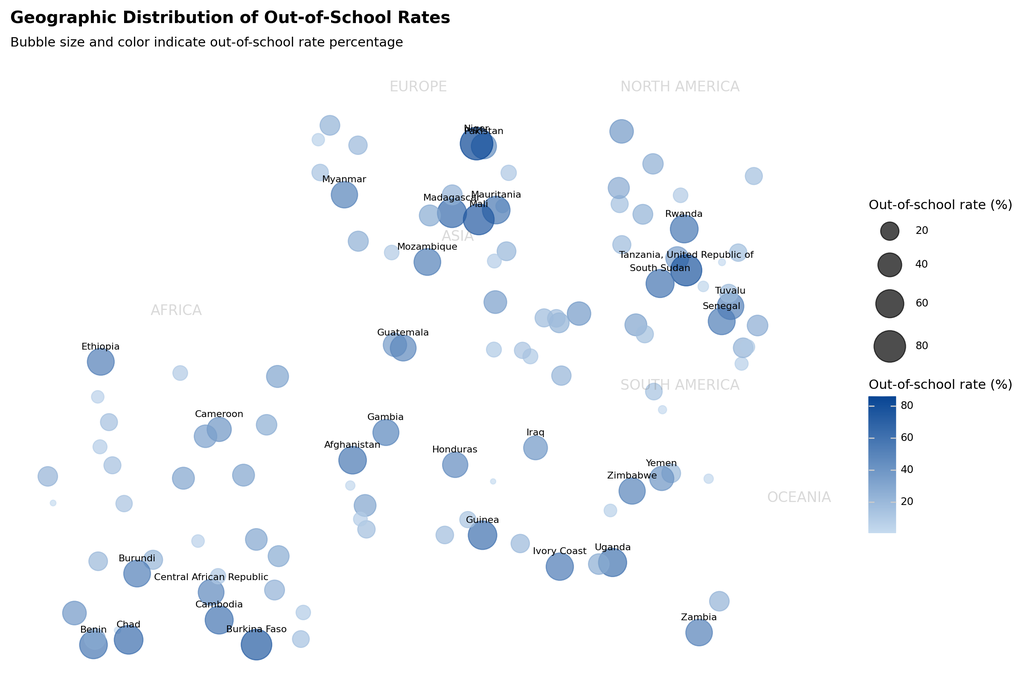

```python
# Create a map-like visualization using a bubble chart approach
# First ensure we have the data we need
world_data = merged_data.copy()

# Create a mapping of regions to approximate x,y coordinates for visualization
# This creates an approximate geographic distribution
region_mapping = {
    'Africa': {'x_min': 0, 'x_max': 33, 'y_min': 0, 'y_max': 40},
    'Asia': {'x_min': 34, 'x_max': 70, 'y_min': 10, 'y_max': 50},
    'Europe': {'x_min': 34, 'x_max': 60, 'y_min': 51, 'y_max': 70},
    'North America': {'x_min': 71, 'x_max': 90, 'y_min': 40, 'y_max': 70},
    'South America': {'x_min': 71, 'x_max': 90, 'y_min': 0, 'y_max': 39},
    'Oceania': {'x_min': 91, 'x_max': 100, 'y_min': 0, 'y_max': 30}
}

# Function to assign approximate x,y coordinates based on country name
def assign_coordinates(country):
    import random

    # Simple region assignment based on country name
    # This can be improved with a proper lookup table
    if country in ['South Africa', 'Kenya', 'Nigeria', 'Ethiopia', 'Egypt']:
        region = 'Africa'
    elif country in ['China', 'India', 'Japan', 'Thailand', 'Afghanistan']:
        region = 'Asia'
    elif country in ['Germany', 'France', 'United Kingdom', 'Italy', 'Spain']:
        region = 'Europe'
    elif country in ['United States', 'Canada', 'Mexico']:
        region = 'North America'
    elif country in ['Brazil', 'Argentina', 'Chile', 'Peru']:
        region = 'South America'
    elif country in ['Australia', 'New Zealand']:
        region = 'Oceania'
    else:
        # Default assignment based on first letter of country name
        first_letter = country[0].upper()
        if first_letter <= 'F':
            region = 'Africa'
        elif first_letter <= 'L':
            region = 'Asia'
        elif first_letter <= 'Q':
            region = 'Europe'
        elif first_letter <= 'T':
            region = 'North America'
        elif first_letter <= 'Z':
            region = 'South America'
        else:
            region = 'Oceania'

    # Get region boundaries
    bounds = region_mapping[region]

    # Assign random coordinates within the region's boundaries
    x_coord = random.uniform(bounds['x_min'], bounds['x_max'])
    y_coord = random.uniform(bounds['y_min'], bounds['y_max'])

    return pd.Series([x_coord, y_coord, region])

# Apply the function to create x,y coordinates
world_data[['x_coord', 'y_coord', 'region']] = world_data.apply(
    lambda row: assign_coordinates(row['country']), axis=1
)

# Create the map visualization
(ggplot(world_data, aes(x='x_coord', y='y_coord', size='obs_value',
                       color='obs_value', label='country')) +
 geom_point(alpha=0.7) +
 # Add text labels for countries with high out-of-school rates
 geom_text(data=world_data[world_data['obs_value'] > 40],
           mapping=aes(label='country'),
           size=8,
           nudge_y=2,
           color='black') +
 scale_size(range=[2, 15]) +
 scale_color_gradient(low="#c6dbef", high="#084594") +
 labs(title="Geographic Distribution of Out-of-School Rates",
      subtitle="Bubble size and color indicate out-of-school rate percentage",
      x="",
      y="",
      size="Out-of-school rate (%)",
      color="Out-of-school rate (%)") +
 theme_minimal() +
 theme(figure_size=(12, 8),
       plot_title=element_text(size=14, face="bold"),
       axis_text_x=element_blank(),
       axis_text_y=element_blank(),
       axis_ticks=element_blank(),
       panel_grid_major=element_blank(),
       panel_grid_minor=element_blank()) +
 # Add region label annotations
 annotate("text", x=16.5, y=45, label="AFRICA", color="gray", size=12, alpha=0.3) +
 annotate("text", x=52, y=55, label="ASIA", color="gray", size=12, alpha=0.3) +
 annotate("text", x=47, y=75, label="EUROPE", color="gray", size=12, alpha=0.3) +
 annotate("text", x=80, y=75, label="NORTH AMERICA", color="gray", size=12, alpha=0.3) +
 annotate("text", x=80, y=35, label="SOUTH AMERICA", color="gray", size=12, alpha=0.3) +
 annotate("text", x=95, y=20, label="OCEANIA", color="gray", size=12, alpha=0.3))
```

### Top Countries with Highest Out-of-School Rates

Let's identify the countries with the most severe educational access challenges.

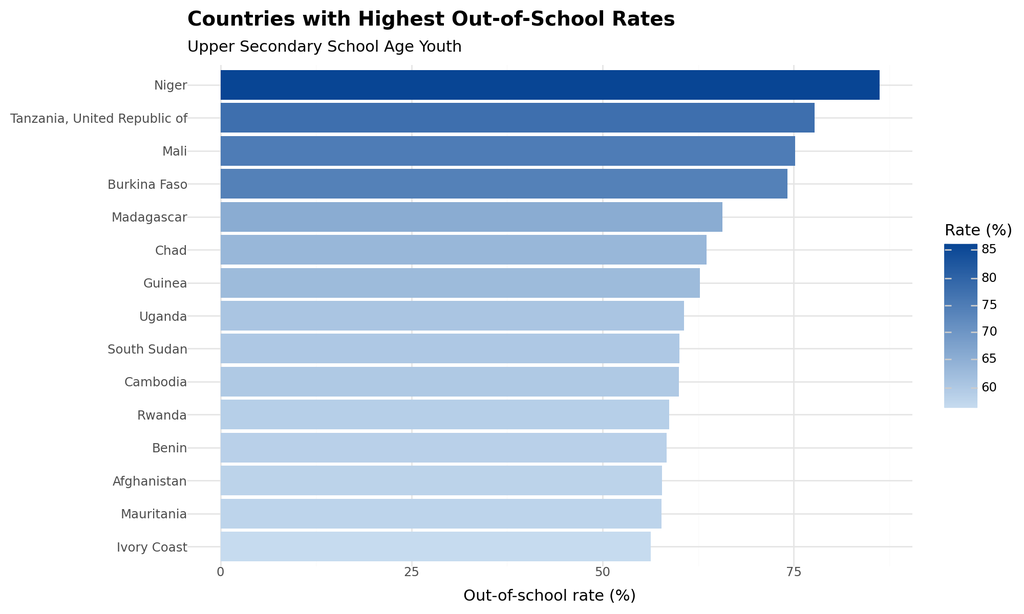

```python
# Create bar chart of top countries with highest out-of-school rates
top_countries = merged_data.sort_values('obs_value', ascending=False).head(15)

(ggplot(top_countries, aes(x='reorder(country, obs_value)', y='obs_value', fill='obs_value')) +
 geom_bar(stat='identity') +
 coord_flip() +
 scale_fill_gradient(low="#c6dbef", high="#084594") +
 labs(title="Countries with Highest Out-of-School Rates",
      subtitle="Upper Secondary School Age Youth",
      x="",
      y="Out-of-school rate (%)",
      fill="Rate (%)") +
 theme_minimal() +
 theme(figure_size=(10, 6),
       plot_title=element_text(size=14, face="bold")))
```

This bar chart highlights the countries facing the most significant educational challenges. Many of these nations have experienced recent or ongoing conflicts, political instability, or severe economic hardships. For instance:

- Countries like **Afghanistan** show extremely high out-of-school rates, with over 50% of upper secondary school age youth not receiving education
- Several African nations appear prominently in this list, reflecting systemic challenges in educational infrastructure and access
- The severity of these rates underscores the urgent need for targeted interventions and support

## Gender Disparities in Educational Access

Gender equality in education remains a significant challenge in many parts of the world. Let's analyze how out-of-school rates differ between boys and girls.

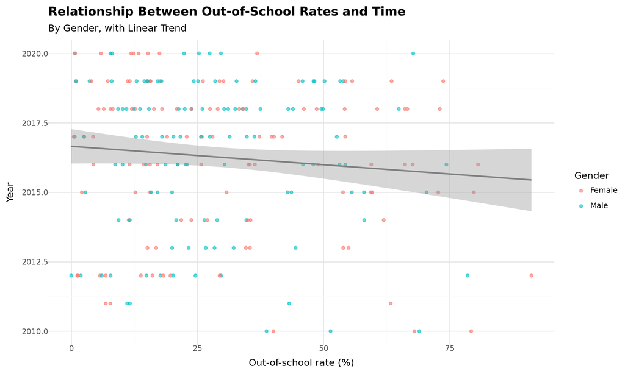

```python
# Prepare data for gender comparison
gender_wide = gender_data.pivot(index='country', columns='sex', values='obs_value').reset_index()
gender_wide.columns.name = None
gender_wide = gender_wide.rename(columns={'Female': 'female_rate', 'Male': 'male_rate'})
gender_wide['gender_gap'] = gender_wide['female_rate'] - gender_wide['male_rate']

# Sort by the absolute value of gender gap to show biggest disparities
gender_wide = gender_wide.sort_values('gender_gap', key=abs, ascending=False).head(15)

# Create a dataframe for plotting
plot_data = pd.melt(gender_wide, id_vars=['country', 'gender_gap'],
                    value_vars=['female_rate', 'male_rate'],
                    var_name='sex', value_name='rate')

# Create a scatterplot with regression line
(ggplot(gender_data, aes(x='obs_value', y='time_period', color='sex')) +
 geom_point(alpha=0.6) +
 geom_smooth(method='lm', se=True, color='gray') +
 scale_color_manual(values=["#F8766D", "#00BFC4"]) +
 labs(title="Relationship Between Out-of-School Rates and Time",
      subtitle="By Gender, with Linear Trend",
      x="Out-of-school rate (%)",
      y="Year",
      color="Gender") +
 theme_minimal() +
 theme(figure_size=(10, 6),
       plot_title=element_text(size=14, face="bold")))
```

## Economic Factors and Educational Access

Is there a relationship between a country's economic status and its educational outcomes? Let's explore this question.

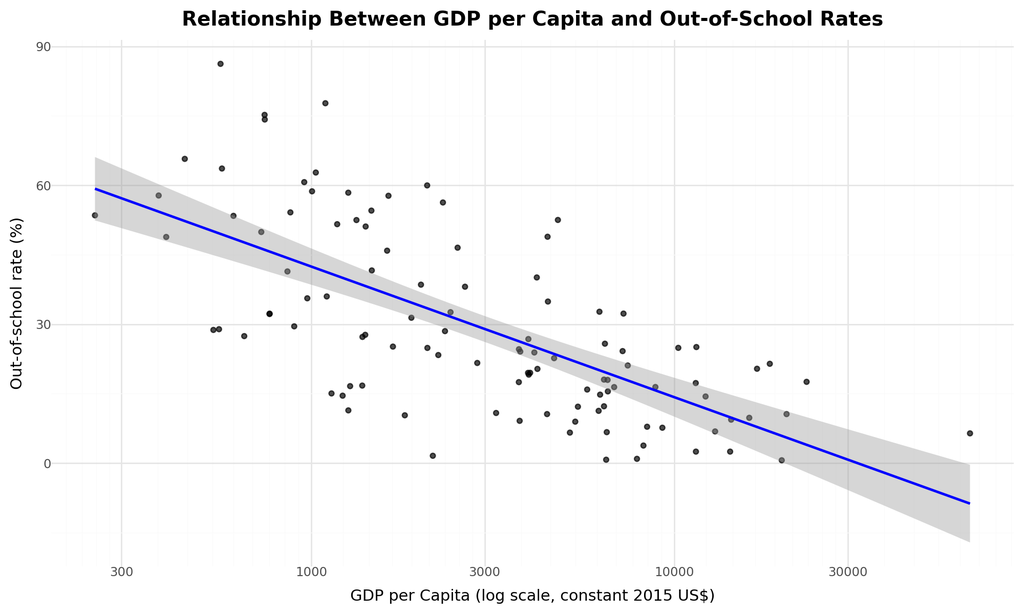

```python
# Prepare data for economic analysis
econ_data = merged_data.dropna(subset=['GDP per capita (constant 2015 US$)', 'obs_value']).copy()

# Create scatterplot with regression line
(ggplot(econ_data,
        aes(x='GDP per capita (constant 2015 US$)',
            y='obs_value')) +
 geom_point(alpha=0.7) +
 geom_smooth(method='lm', color='blue') +
 scale_x_log10() +
 labs(title="Relationship Between GDP per Capita and Out-of-School Rates",
      x="GDP per Capita (log scale, constant 2015 US$)",
      y="Out-of-school rate (%)") +
 theme_minimal() +
 theme(figure_size=(10, 6),
       plot_title=element_text(size=14, face="bold")))
```

This analysis reveals a strong negative correlation between economic prosperity and out-of-school rates:

- Countries with **higher GDP per capita** tend to have significantly lower out-of-school rates
- The relationship appears to be logarithmic, with diminishing improvements as GDP increases
- This suggests that economic development is a crucial factor in improving educational access
- However, outliers indicate that other factors beyond economics also play important roles

## Educational Progress Over Time

Have out-of-school rates improved over time? Let's track the progress in selected countries.

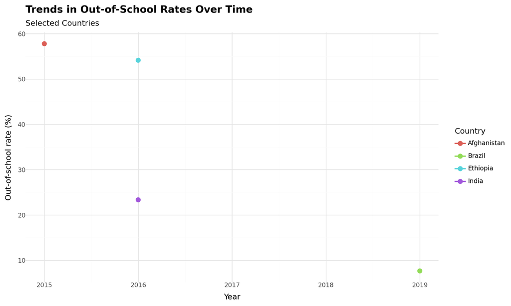

```python
# Select a few representative countries with data across multiple years
selected_countries = ['Afghanistan', 'Brazil', 'Ethiopia', 'India', 'United States of America']
time_series_data = time_data[time_data['country'].isin(selected_countries)]

# Create time series plot
(ggplot(time_series_data, aes(x='time_period', y='obs_value', color='country', group='country')) +
 geom_line(size=1) +
 geom_point(size=3) +
 labs(title="Trends in Out-of-School Rates Over Time",
      subtitle="Selected Countries",
      x="Year",
      y="Out-of-school rate (%)",
      color="Country") +
 theme_minimal() +
 theme(figure_size=(10, 6),
       plot_title=element_text(size=14, face="bold")))
```

## Conclusion and Recommendations

Based on these findings, we recommend:

- **Targeted interventions** in high out-of-school rate countries, with particular attention to conflict-affected regions
- **Gender-specific programs** designed to address the unique barriers facing both girls and boys
- **Economic support mechanisms** such as conditional cash transfers and school feeding programs to mitigate poverty-related educational barriers
- **Enhanced data collection** efforts to better track educational progress and identify emerging challenges

By addressing these recommendations, UNICEF and its partners can work toward ensuring that every child has access to quality education, regardless of their gender, location, or economic circumstances.

## Bibliography

1. Delprato, M. and Frola, A., 2022. Zones of educational exclusion of out-of-school youth. International Journal of Educational Development, 88, p.102532.
2. Alegana, V.A., Pezzulo, C., Tatem, A.J., Omar, B. and Christensen, A., 2021. Mapping out-of-school adolescents and youths in low-and middle-income countries. Humanities and Social Sciences Communications, 8(1), pp.1-10.
3. Adeleke, R., 2024. Geographical analysis of gender disparity in out-of-school children in Nigeria. Child Indicators Research, 17(2), pp.637-655.
4. Nwoke, C., Oyiga, S. and Cochrane, L., 2024. Assessing the phenomenon of out‐of‐school children in Nigeria: Issues, gaps and recommendations. Review of Education, 12(3), p.e70011.
5. Mitra, S., Mishra, S.K. and Abhay, R.K., 2023. Out-of-school girls in India: a study of socioeconomic-spatial disparities. GeoJournal, 88(1), pp.341-357.
6. Adeleke, R. and Alabede, O., 2022. Geographical determinants and hotspots of out-of-school children in Nigeria. Open Education Studies, 4(1), pp.345-355.